# 02 Analysis

Last update: 2021-03-30

We analysed 60k search results from each search engine and came up with some interesting insights.

# 1 Summary of insights

1. DuckDuckGo is the most accurate search engine when compared to Google. Google’s #1 search result was found in DuckDuckGo’s top 10 67.3% of the time. Bing is close with 66.3% and Yahoo worse at 62.2%.
2. For all search engines, we see that accuracy slightly improves for high volume, with gains between 1.5% and 2% when comparing volume of more and less than 10k.
3. The accuracy of the search engines differs by category. Real Estate, Travel & Tourism, and Retailers & General Merchandise are more accurate across *all* search engines. While Apparel, Beauty & Personal Care, and Home & Garden are less accurate.
4. Accuracy is better for single word searches and for long searches.
5. The top results of Googles’s competitors are much more similar between themselves than similar to Google’s.
6. The different search engines feature in different amounts big domains such as amazon in their top result.
7. Searches that tend to yield results predominantly linking to a specific domain (domain specific), OR non domain specific at all, show higher accuracy on average.
8. In more than half of the cases in any search engine, google’s top result is found in position 1 to 3.
9. Accuracy varies on average depending on the domain extension of google’s top result.

# 2 Research questions

See here an example example articles we did in the past to get an idea for the end result and the type of findings we´re looking for: https://backlinko.com/Google-ctr-stats; https://backlinko.com/page-speed-stats

```r
library(tidyverse) # package used for data wrangling
# options(dplyr.summarise.inform = F)
theme_set(theme_minimal() +
            theme(plot.title = element_text(size = 15)))
# "datasets_for_report.Rdata" is built by the following commented calls
# source(here::here("scripts/01_build_light_dataset.R"))
# source(here::here("scripts/02_build_datasets_for_report.R"))
load(here::here("proc_data/datasets_for_report.Rdata"))
```

# 3 Analysis

## 3.1 How accurate are the other search engines?

We developed an accuracy measure that counts how many times a search engines results contains Google’s #1 result in their top 10.

If the search engine contained Google’s #1 result for all of their keywords their accuracy would be 100%. While if they did not, their accuracy would be 0%.

We show below the accuracy for each search engine using the top 10 as well as the top 20 and top 30 results.

We see that Yahoo is fairly behind both competitors and DuckDuckGo has a slight edge over Bing.

```r
accuracy_by_se
```

```
## # A tibble: 3 x 5
##   search_engine accuracy_top_10 accuracy_top_20 accuracy_top_30 n_keywords
##   <chr>                   <dbl>           <dbl>           <dbl>      <int>
## 1 DuckDuck                0.673           0.728           0.740      54072
## 2 Bing                    0.663           0.726           0.746      54072
## 3 Yahoo                   0.622           0.665           0.677      54072
```

For the rest of the report, unless stated otherwise, accuracy is computed by considering the top 10 results only.

## 3.2 Monthly search volume

The sample of 60k search keywords were chosen so we got a fairly even split across different search volumes.

```r
monthly_search_volume
```

```
## # A tibble: 3 x 2
##   monthly_search_volume_level Count
##   <fct>                       <chr>
## 1 500-1000                    19,763
## 2 1000-10000                  19,793
## 3 10000-100000                19,823
```

We show below how search volume affects the accuracy of the search engines, considering the top 10, 20 or 30 results.

We see an improvement for volumes over 10K searches per month.

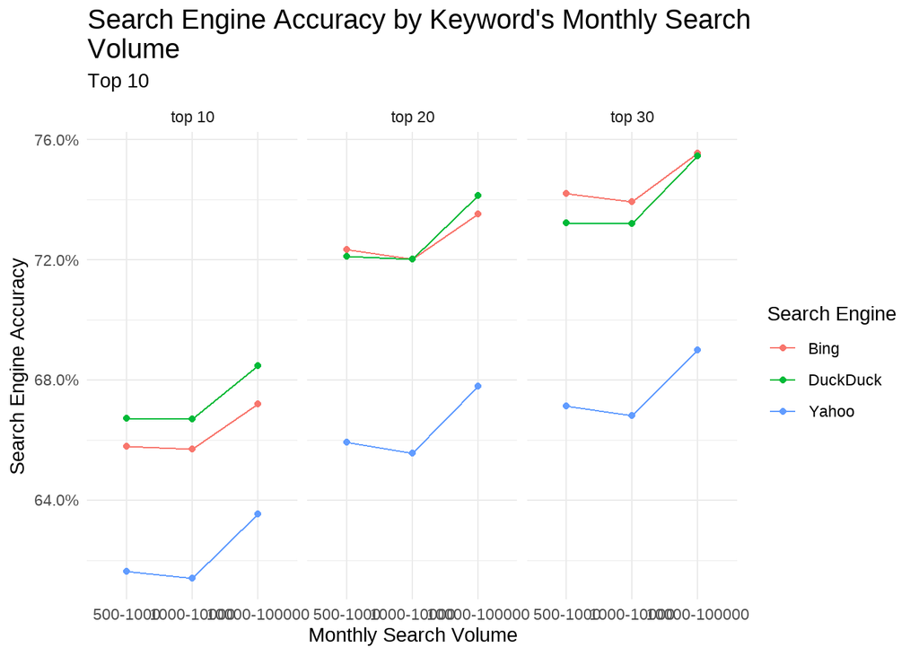

```r
accuracy_by_se_and_vol %>%
  ggplot(aes(monthly_search_volume_level, y = accuracy, colour = search_engine,
             group = search_engine)) +
  geom_line() +
  geom_point() +
  scale_y_continuous(labels = scales::label_percent()) +
  labs(title = str_wrap("Search Engine Accuracy by Keyword's Monthly Search Volume", 50),
       subtitle = "Top 10",
       colour = "Search Engine",
       x = "Monthly Search Volume",
       y = "Search Engine Accuracy") +
  facet_wrap(vars(grp), ncol = 3)
```

## 3.3 Keyword categories

Each of the keywords comes with categories (or tags). It’s possible for keywords to belong to more than one category. The sample of 60k keywords was drawn randomly so we don’t expect to have an equal amount in each category.

The most common categories are News, Media & Publications, Arts & Entertainment, Business & Industrial, and Hobbies & Leisure.

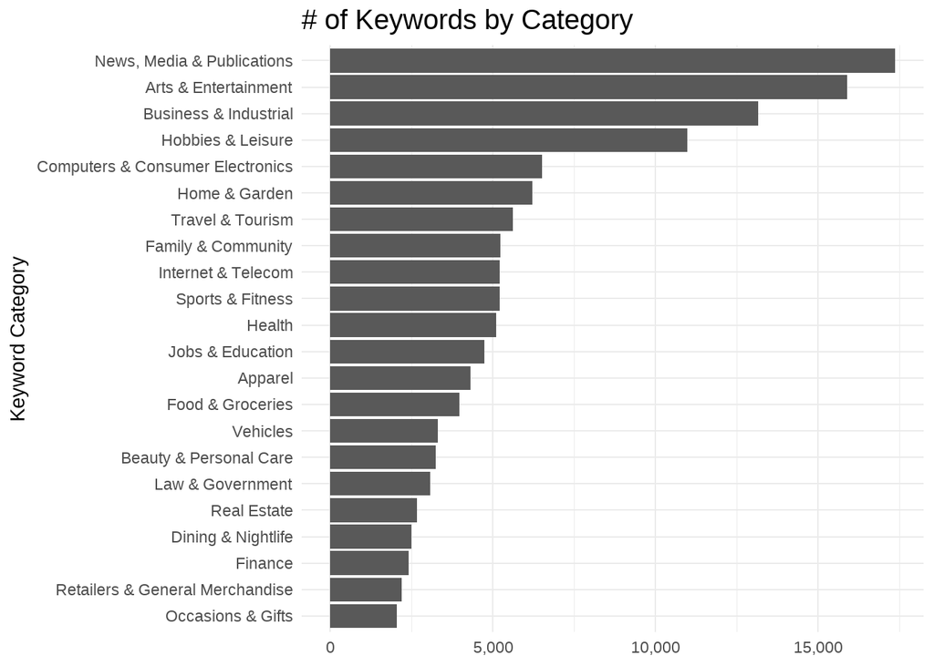

```r
category1_counts %>%
  ggplot(aes(x = keyword_category, y = n)) +
  geom_col() +
  coord_flip() +
  scale_y_continuous(labels = scales::label_comma()) +

  labs(title = "# of Keywords by Category",
       x = "Keyword Category",
       y = NULL)
```

Deeper levels of categories are available, nested into the main categories, we show below the breakdown of the level 2 and 3 categories.

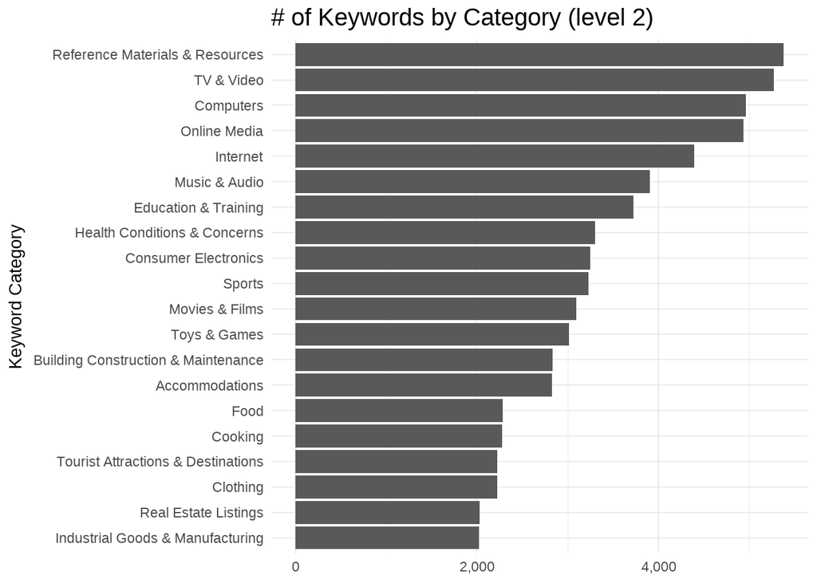

```r
category2_counts %>%
  ggplot(aes(x = keyword_category, y = n)) +
  geom_col() +
  coord_flip() +
  scale_y_continuous(labels = scales::label_comma()) +

  labs(title = "# of Keywords by Category (level 2)",
       x = "Keyword Category",
       y = NULL)
```

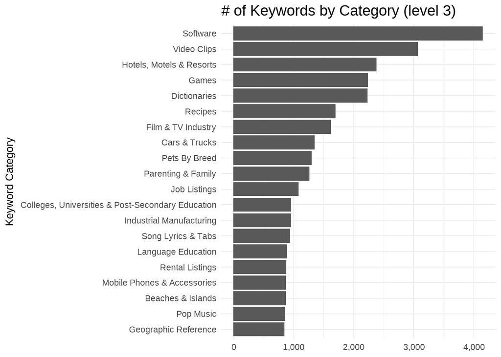

```r
category3_counts %>%
  ggplot(aes(x = keyword_category, y = n)) +
  geom_col() +
  coord_flip() +
  scale_y_continuous(labels = scales::label_comma()) +

  labs(title = "# of Keywords by Category (level 3)",
       x = "Keyword Category",
       y = NULL)
```

The following chart shows that there is significant variance in accuracy depending on what category the keyword belongs too. Real Estate, Travel & Tourism, Retailers & General Merchandise, and Dining & Nightlife are the four most accurate categories across all the search engines (between 67% and 75%). While Home & Garden and Apparel are least accurate (between 55% and 61%).

Yahoo is also particularly less accurate in a couple of categories. For example, in Health Yahoo is 60% accurate (vs ~67% for the other two search engines). Similarly for Food & Groceries, and Beauty & Personal Care.

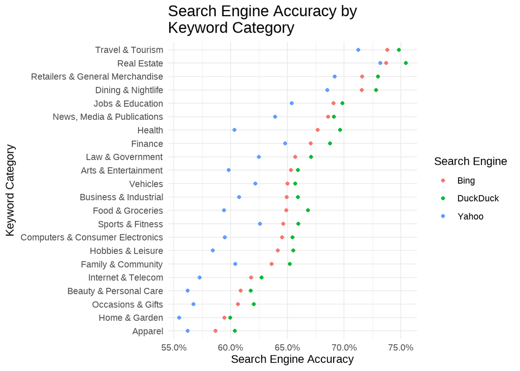

```r
accuracy_by_se_and_category %>%
  ggplot(aes(x = keyword_category, y = accuracy,
             group = search_engine, colour = search_engine)) +
  geom_point() +
  coord_flip() +
  scale_y_continuous(labels = scales::label_percent()) +
  labs(title = str_wrap("Search Engine Accuracy by Keyword Category", 30),
       # subtitle = "Top 10",
       colour = "Search Engine",
       x = "Keyword Category",
       y = "Search Engine Accuracy")
```

We reproduce this chart for the 10 biggest subcategories of level 2 and 3.

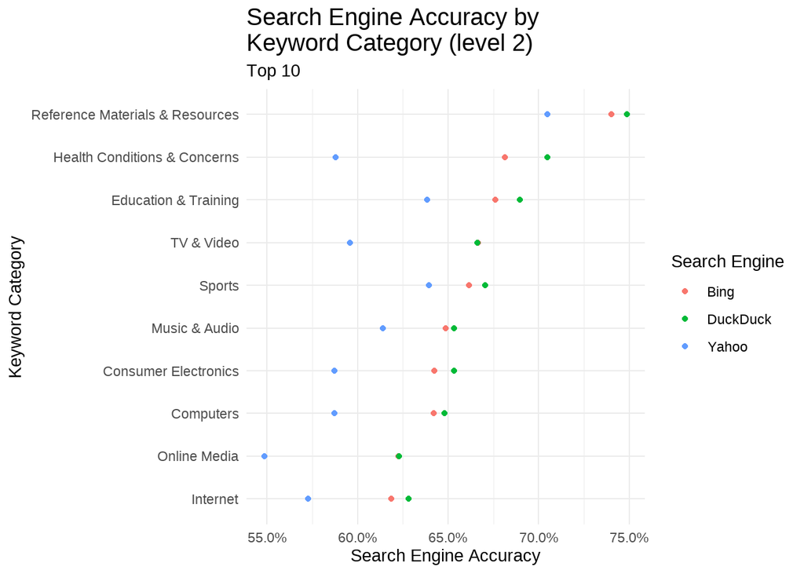

```r
accuracy_by_se_and_category_2 %>%
  ggplot(aes(x = keyword_category, y = accuracy,
             group = search_engine, colour = search_engine)) +
  geom_point() +
  coord_flip() +
  scale_y_continuous(labels = scales::label_percent()) +
  labs(title = str_wrap("Search Engine Accuracy by Keyword Category (level 2)", 30),
       subtitle = "Top 10",
       colour = "Search Engine",
       x = "Keyword Category",
       y = "Search Engine Accuracy")
```

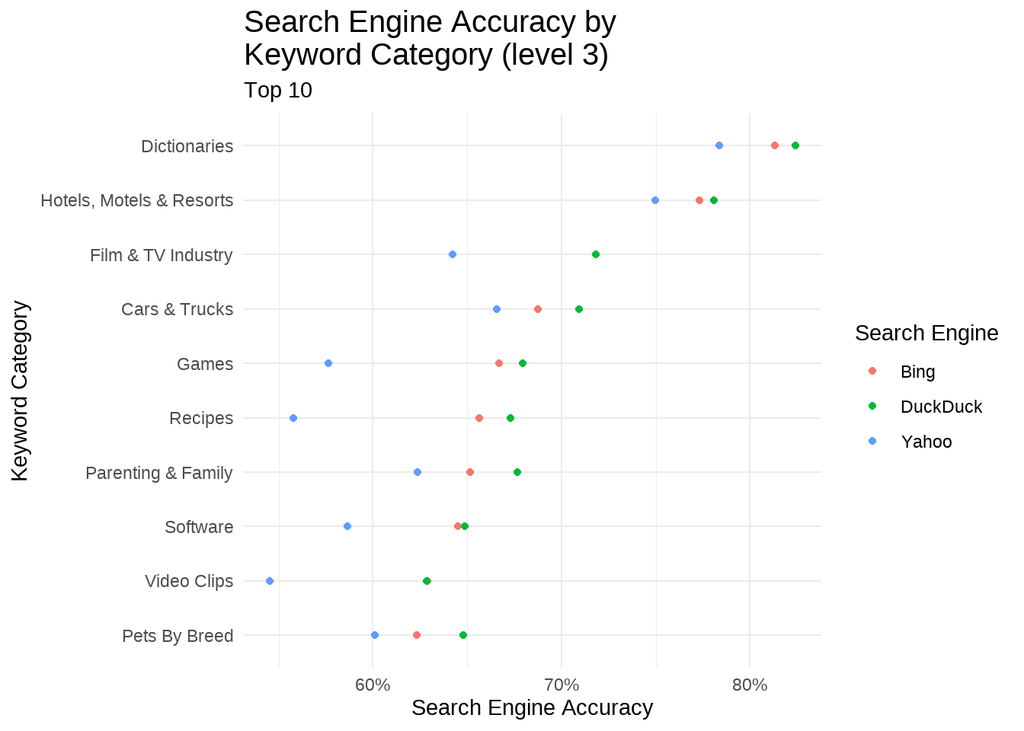

```r
accuracy_by_se_and_category_3 %>%
  ggplot(aes(x = keyword_category, y = accuracy,
             group = search_engine, colour = search_engine)) +
  geom_point() +
  coord_flip() +
  scale_y_continuous(labels = scales::label_percent()) +
  labs(title = str_wrap("Search Engine Accuracy by Keyword Category (level 3)", 30),
       subtitle = "Top 10",
       colour = "Search Engine",
       x = "Keyword Category",
       y = "Search Engine Accuracy")
```

Finally we offer a breakdown of the accuracy by main category and volume category.

We see that volume can make a big difference in some cases, for instance for Health related keywords Bing and DuckDuck become much more accurate as volume increases.

We see also that Real Estate related searches give the most accurate results accross categories at lower volume.

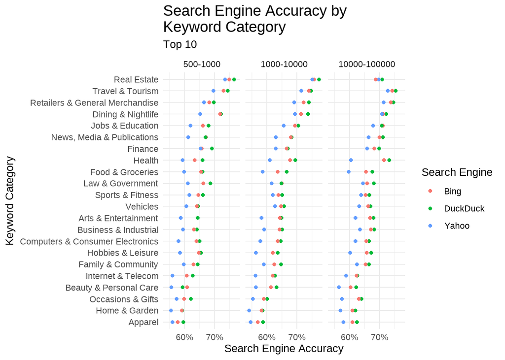

```r
accuracy_by_se_category_and_vol %>%
  ggplot(aes(x = keyword_category, y = accuracy,
             group = search_engine, colour = search_engine)) +
  geom_point() +
  coord_flip() +
  facet_wrap(vars(monthly_search_volume_level)) +
  scale_y_continuous(labels = scales::label_percent()) +
  labs(title = str_wrap("Search Engine Accuracy by Keyword Category", 30),
       subtitle = "Top 10",
       colour = "Search Engine",
       x = "Keyword Category",
       y = "Search Engine Accuracy")
```

Below we show, both for small and medium volume (resp. 500-1000 and 1000-10000), 5 examples of Real Estate keywords for which we found the same url on the top for every search engine.

```
## # A tibble: 5 x 2
##   keyword           url
##   <chr>             <chr>
## 1 st jacob          https://en.wikipedia.org/wiki/Jacob_of_Nisibis
## 2 delevan, ny       https://www.mapquest.com/us/new-york/delevan-ny-282022044
## 3 housing minnesota http://www.mnhousing.gov/
## 4 uhaul hattiesbur~ https://www.uhaul.com/Locations/Truck-Rentals-near-Hattiesb~
## 5 indian land publ~ https://www.publix.com/locations/1412-cross-creek
```

```
## # A tibble: 5 x 2
##   keyword                            url
##   <chr>                              <chr>
## 1 jj keller permits                  https://www.kellerpermits.com/
## 2 car registration ny                https://dmv.ny.gov/registrations-0
## 3 colorado springs housing authority https://csha.us/
## 4 marana, arizona                    https://www.maranaaz.gov/
## 5 1911 build kit                     https://www.1911builders.com/
```

## 3.4 Number of words

Most keywords (search terms) have between 2 and 4 words. There are also 29 search terms that have at least 10 words. For example `what are the first ten amendments to the constitution called` and `how long does it take to become a pediatric nurse`.

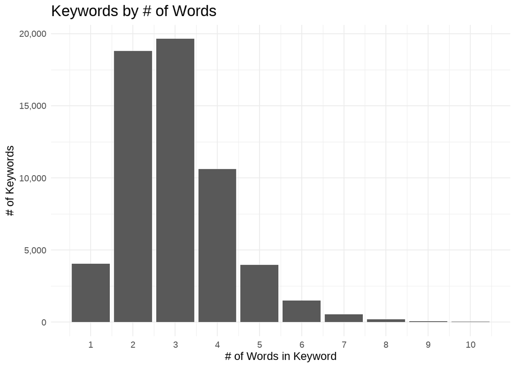

```r
kw_length_counts %>%
  ggplot(aes(x = keyword_length, y = n)) +
  geom_col() +
  scale_x_continuous(breaks = seq(0, 10, 1)) +
  labs(title = "Keywords by # of Words",
       y = "# of Keywords",
       x = "# of Words in Keyword") +
  scale_y_continuous(labels = scales::label_comma())
```

For all three search engines, the search terms with only one word are the most accurate, but we observe a “U” shape curve as longer keywords show more accurate results than medium length ones.

On average accuracy for length 1 keywords is about 5% higher than for length 2, and this difference is bigger for high volumes.

There might be two forces at play here, on one hand single word searches are more straightforward, so we can expect search engines to converge more on them, and on the other hand long keywords are more precise, so the pool of potential targets decreases with the length of the search and long searches tend to converge over search engines too.

Searching for a brand name for instance, we expect to find the official website on the first result on all search engines, and searching for a blog article by typing its full title we expect all search engines to propose it first as well.

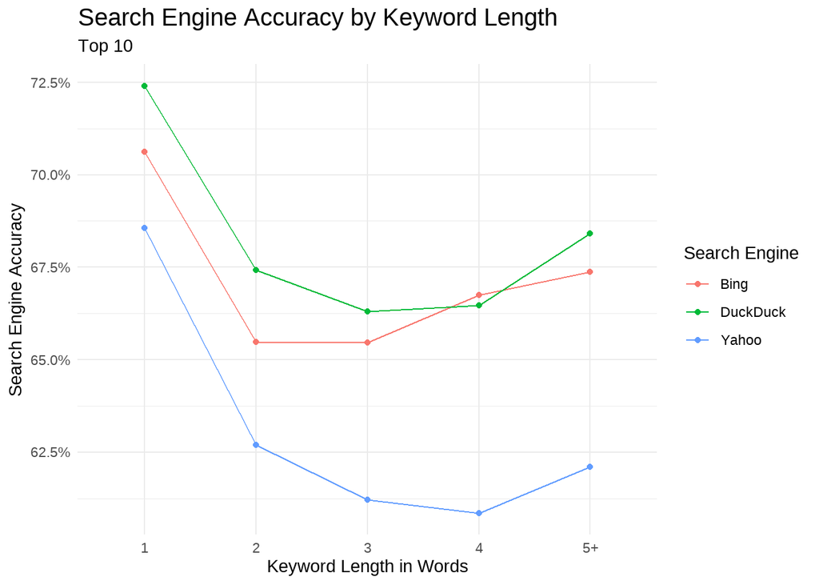

```r
accuracy_by_se_and_kw_length %>%
  ggplot(aes(keyword_length, y = accuracy, colour = search_engine,
             group = search_engine)) +
  geom_line() +
  geom_point() +
  scale_y_continuous(labels = scales::label_percent()) +
  labs(title = str_wrap("Search Engine Accuracy by Keyword Length", 50),
       subtitle = "Top 10",
       colour = "Search Engine",
       x = "Keyword Length in Words",
       y = "Search Engine Accuracy")
```

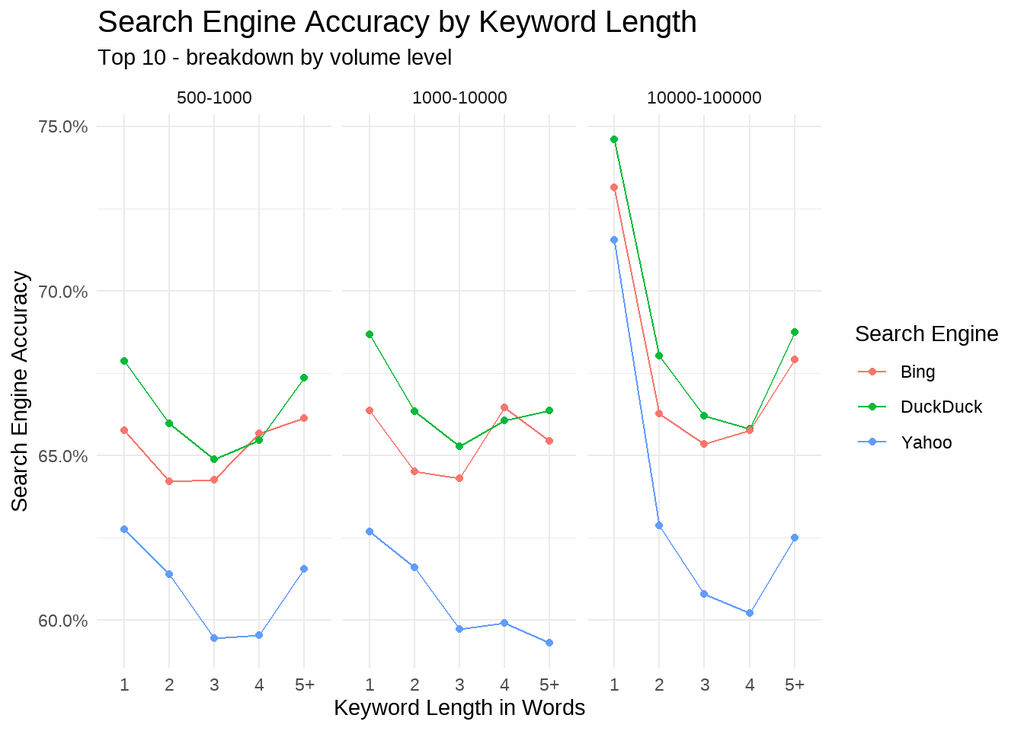

```r
accuracy_by_se_vol_and_kw_length %>%
  ggplot(aes(keyword_length, y = accuracy, colour = search_engine,
             group = search_engine)) +
  geom_line() +
  geom_point() +
  scale_y_continuous(labels = scales::label_percent()) +
  labs(title = str_wrap("Search Engine Accuracy by Keyword Length", 50),
       subtitle = "Top 10 - breakdown by volume level",
       colour = "Search Engine",
       x = "Keyword Length in Words",
       y = "Search Engine Accuracy") +
  facet_wrap(vars(monthly_search_volume_level), ncol=3)
```

Below we show, both for single word searches and long searches, 5 examples for which we found the same url on the top for every search engine.

We see that the single word searches are either technical words, linking to wikipedia definitions, or brand names , linking to their official webpage.

Long searches are more specific, for instance one long search links to a blog article titled almost like the search, the format “best pizza in san diego little italy” is taylored for yelp and all the search engines agree easily on the result to put at the top.

```
## # A tibble: 5 x 3
##   keyword        domain             url
##   <chr>          <chr>              <chr>
## 1 estimators     en.wikipedia.org   https://en.wikipedia.org/wiki/Estimator
## 2 endopeptidases en.wikipedia.org   https://en.wikipedia.org/wiki/Endopeptidase
## 3 pccasegear     www.pccasegear.com https://www.pccasegear.com/
## 4 myrts          www.myrts.com      https://www.myrts.com/
## 5 dripdrop       dripdrop.com       https://dripdrop.com/
```

```
## # A tibble: 5 x 3
##   keyword                domain           url
##   <chr>                  <chr>            <chr>
## 1 how much savings shou~ www.daveramsey.~ https://www.daveramsey.com/blog/how-m~
## 2 cheapest place to get~ www.goodrx.com   https://www.goodrx.com/shingrix
## 3 foster a dog san fran~ www.sfspca.org   https://www.sfspca.org/foster/
## 4 black rock bar and gr~ www.blackrockre~ https://www.blackrockrestaurants.com/
## 5 best pizza in san die~ www.yelp.com     https://www.yelp.com/search?find_desc~
```

## 3.5 How similar are the rankings between search engines?

We define similarity between two search engines as the fraction of results (identified by url) that we find in both top 10 results of the pair.

We see below that on average 71% of top 10 results on yahoo can be also found in the top 10 of Bing, making them the most similar pair.

Google is very dissimilar to other search engines, especially Yahoo, its shares only 29% of top 10 results wit the latter.

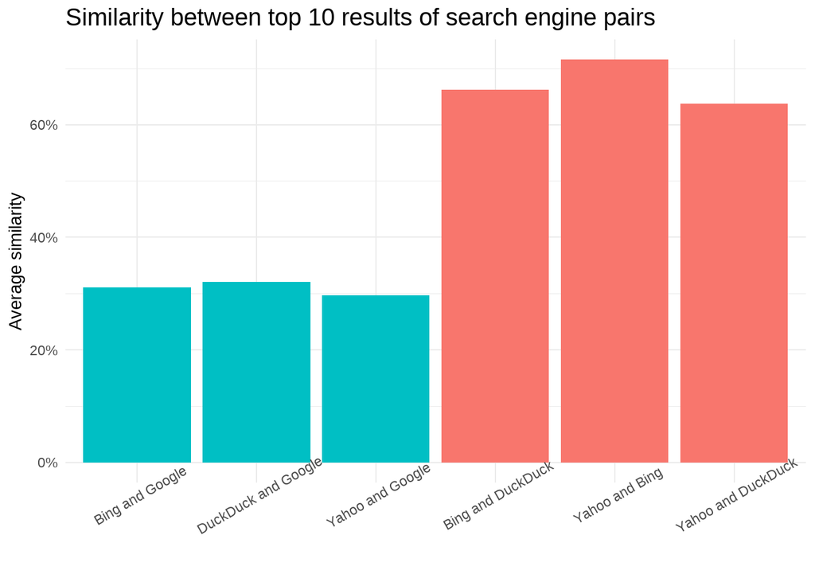

We show below the same chart but this time considering only the similarity between top 3. We see overall that top3 results are more similar than top 10 results. It makes sense as the higher we are on the page the less random should be the results, and those should converge between search engines.

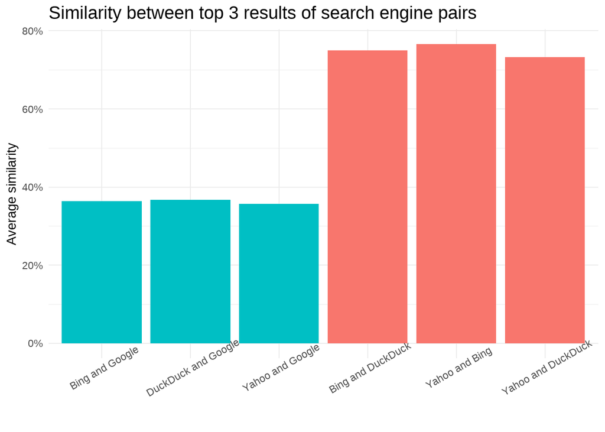

## 3.6 Top domains

We take a look at the top 10 domains featured in 1st position of Google searches and see for which proportion of keyword they come up on top.

We see that search engines vary sensibly in which domain they put on top.

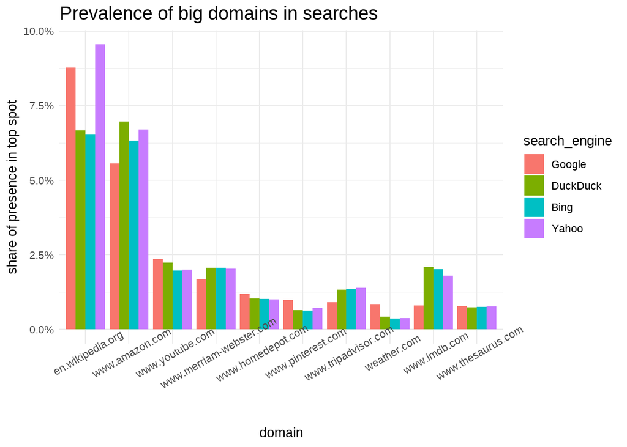

We reproduce the analysis considering the whole top 10 results rather than only the top result.

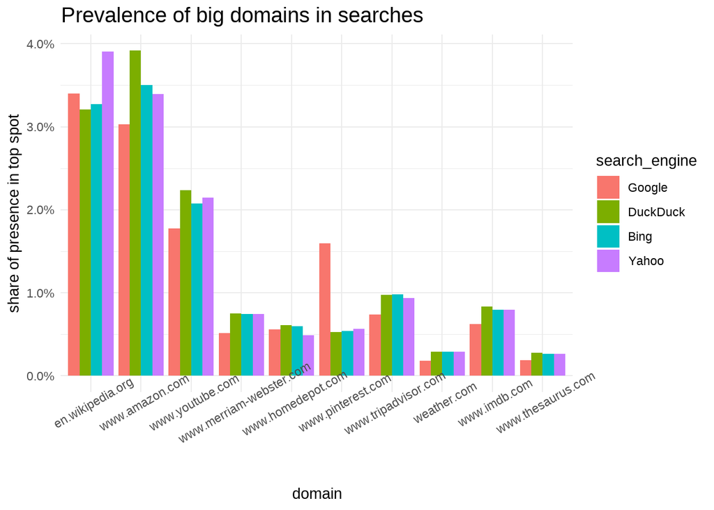

## 3.7 Domain specificity

We define the domain specificity of a keyword as the number of top 10 Google results that feature the dominant domain of this top 10. For instance a research that returns 3 ebay results, 5 amazon results, and 2 other results, would be dominated by amazon, so would be considered “amazon specific”, and would be attributed a domain specificity of 5.

We observe a U shape curve here too, searches that are very domain specific, or not at all, show the most accuracy. It might be that moderate domain specificity is a symptom of an unclear search, while very high domain specificity shows that the search was more targetted.

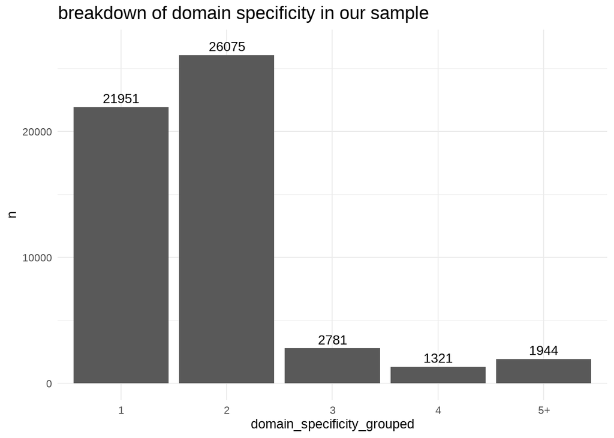

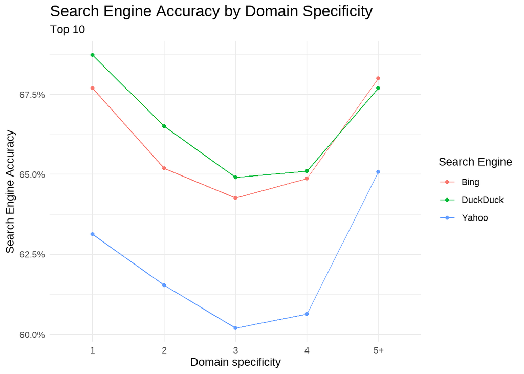

## 3.8 At what position is Google’s first result ?

We take a look at the position at which we find the first Google result in the results of the competitors.

The most likely position of the first Google result is 1st. For every search engine, around 35% of keywords will have Google’s first result on top.

For every search engine, in 12% of the cases, the the first Google result is found in second position.

The second most likely position is that it’s not found at all in the top 30.

A fair amount of google first results are not found at all by other search engines, at least not in the top 30, so we cannot compute a mean position, but we see that for every other search engine, we find google’s top results in the top 3 more than half of the time.

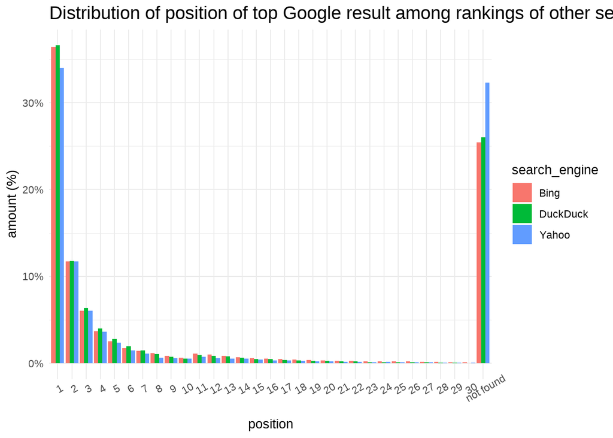

```
## # A tibble: 4 x 2
##   search_engine median
##   <chr>          <dbl>
## 1 Bing               3
## 2 DuckDuck           3
## 3 Google             1
## 4 Yahoo              3
```

## 3.9 How does accuracy vary with domain extension

We look at the domain extension of the domain of google’s first search and observe how it affects accuracy.

We see that accuracy is much better when google’s top result points to a “.info” or “.org” website than when it points to a “.uk” or “.ca” website.

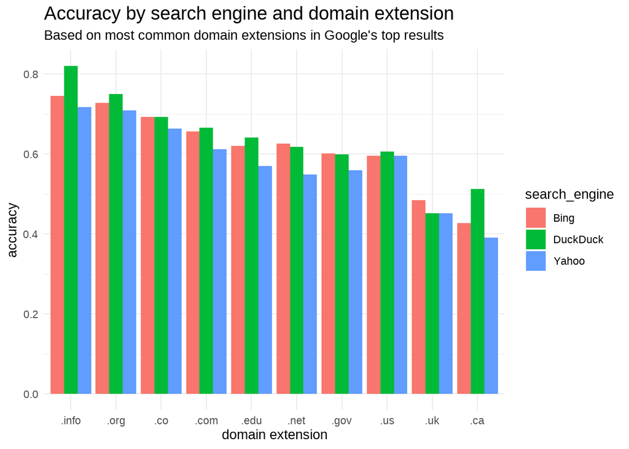